# IS6400 Week 3 Assignment – Solution

## 2.3 Feature–target relationships

### 2.3.1 `property_type` (nominal)

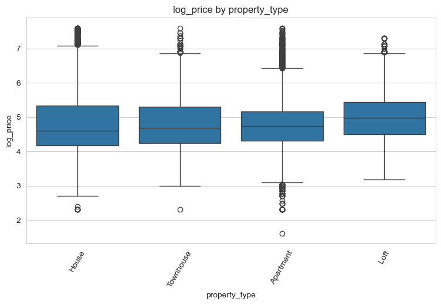

| property_type | count | median | std |
| --- | --- | --- | --- |
| Loft | 1239 | 4.976734 | 0.745645 |
| Apartment | 48772 | 4.744932 | 0.641154 |
| Townhouse | 1690 | 4.691348 | 0.799160 |
| House | 16432 | 4.605170 | 0.876550 |

```python
plt.figure(figsize=(9, 5))
order = air_clean.groupby('property_type')['log_price'].median().sort_values().index
sns.boxplot(data=air_clean, x='property_type', y='log_price', order=order)
plt.xticks(rotation=60)
plt.title('log_price by property_type')
plt.ylabel('log_price')
plt.show()

air_clean.groupby('property_type')['log_price'].agg(['count', 'median', 'std']).sort_values('median', ascending=False).head(6)
```

### 2.3.2 `accommodates` (ratio, discrete)

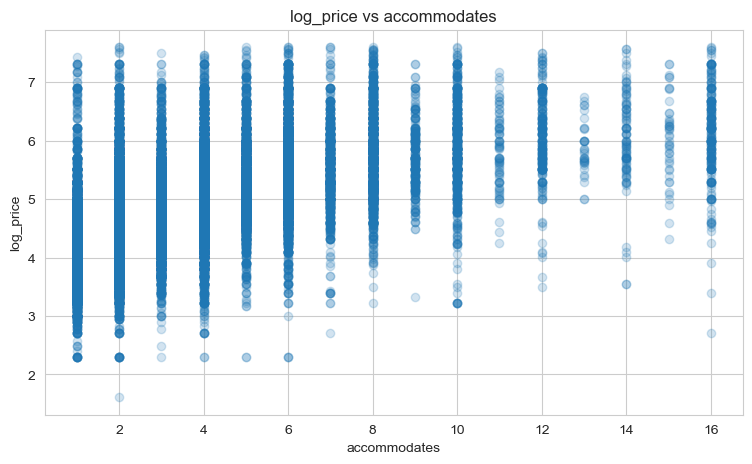

```
Correlation: 0.578
Median log_price by accommodates:
accommodates
1     4.143
2     4.500
3     4.812
4     5.011
5     5.220
6     5.416
7     5.521
8     5.704
9     5.700
10    5.858
Name: log_price, dtype: float64
```

```python
plt.scatter(air_clean['accommodates'], air_clean['log_price'], alpha=0.2)
plt.xlabel('accommodates')
plt.ylabel('log_price')
plt.title('log_price vs accommodates')
plt.show()

print("Correlation:", round(air_clean['accommodates'].corr(air_clean['log_price']), 3))
print("Median log_price by accommodates:")
print(air_clean.groupby('accommodates')['log_price'].median().head(10).round(3))
```

### 2.3.3 `bathrooms` (ratio, continuous)

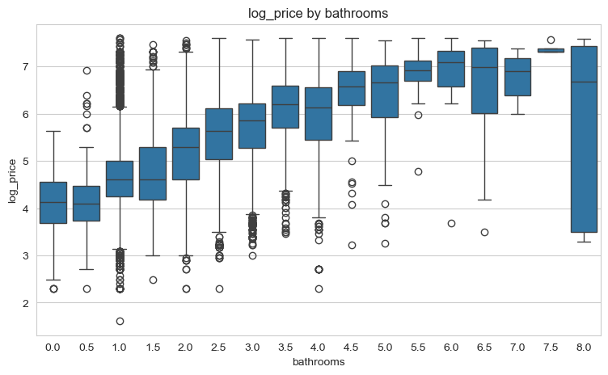

```
Correlation: 0.377
Median log_price by bathrooms:
bathrooms
0.0    4.127
0.5    4.094
1.0    4.605
1.5    4.605
2.0    5.293
2.5    5.635
3.0    5.852
3.5    6.205
Name: log_price, dtype: float64
```

```python
sns.boxplot(data=air_clean, x='bathrooms', y='log_price')
plt.title('log_price by bathrooms')
plt.show()

print("Correlation:", round(air_clean['bathrooms'].corr(air_clean['log_price']), 3))
print("Median log_price by bathrooms:")
print(air_clean.groupby('bathrooms')['log_price'].median().head(8).round(3))
```

### 2.3.4 `review_scores_rating` (interval)

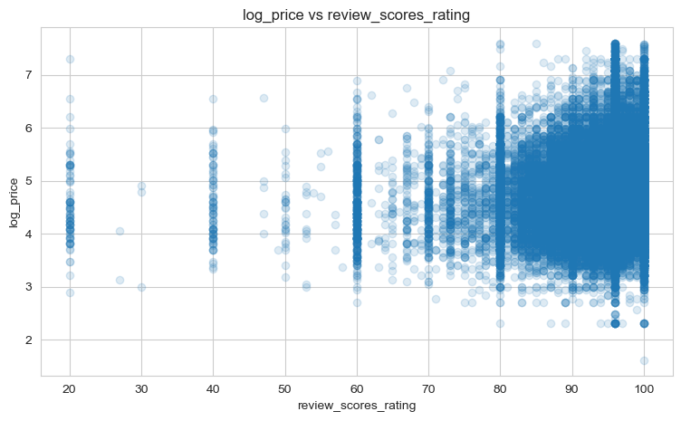

```
Correlation: 0.081
```

```python
plt.scatter(air_clean['review_scores_rating'], air_clean['log_price'], alpha=0.15)
plt.xlabel('review_scores_rating')
plt.ylabel('log_price')
plt.title('log_price vs review_scores_rating')
plt.show()

print("Correlation:", round(air_clean['review_scores_rating'].corr(air_clean['log_price']), 3))
```

**Interpretation:** Nearly no linear correlation. Rating is very concentrated (near 100) and has little explanatory power for price.

### 2.3.5 `bedrooms` (ratio, discrete)

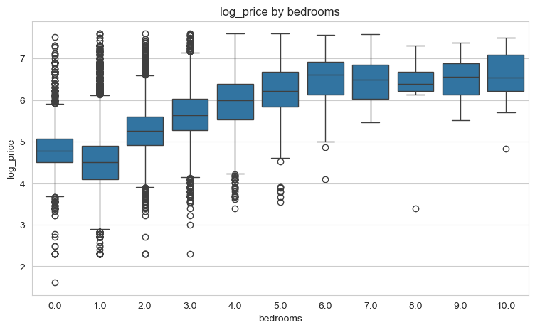

```
Correlation: 0.483
```

```python
sns.boxplot(data=air_clean, x='bedrooms', y='log_price')
plt.title('log_price by bedrooms')
plt.show()

print("Correlation:", round(air_clean['bedrooms'].corr(air_clean['log_price']), 3))
```

**Interpretation:** Positive relationship, similar to `accommodates`. Correlation ≈ 0.50. Bedroom count is a proxy for listing size and thus drives price.

### 2.3.6 `beds` (ratio, discrete)

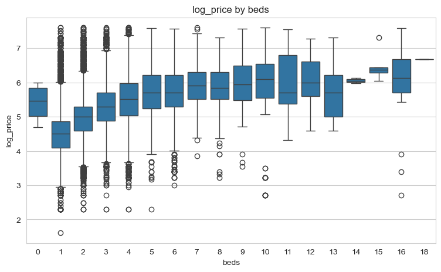

```
Correlation: 0.47
```

```python
sns.boxplot(data=air_clean, x='beds', y='log_price')
plt.title('log_price by beds')
plt.show()

print("Correlation:", round(air_clean['beds'].corr(air_clean['log_price']), 3))
```

## 2.4 Correlation and causation

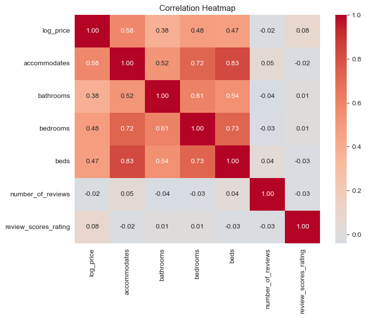

```python
corr_cols = ['log_price', 'accommodates', 'bathrooms', 'bedrooms',
             'beds', 'number_of_reviews', 'review_scores_rating']

corr_matrix = air_clean[corr_cols].corr()

plt.figure(figsize=(8, 6))
sns.heatmap(corr_matrix, annot=True, fmt='.2f', cmap='coolwarm', center=0)
plt.title('Correlation Heatmap')
plt.show()
```

```python
top_corr = corr_matrix['log_price'].drop('log_price').sort_values(key=abs, ascending=False).head(3)
top_corr.round(3)
```

```
accommodates    0.578
bedrooms        0.483
beds            0.470
Name: log_price, dtype: float64
```

**Top 3 correlated features with `log_price`:**

**Correlation does not imply causation.** Consider `accommodates` and `log_price`. Bigger apartments do not *cause* higher prices by themselves. Location, amenities, host reputation, and demand are confounding variables that simultaneously increase listing capacity and price. A causal statement would require a controlled experiment (e.g., listing the same apartment with different capacity settings) or a careful quasi-experimental design.

# Question 3 – Project Dataset Exploration

This section is a placeholder for the course project dataset.  
Below is a template approach that can be adapted to any dataset.

```python
# Replace with your own project dataset
# project = pd.read_csv('project_data.csv')
# project.head()
```

### Template procedure

1. **Shape, dtypes, missing values.**
2. **Attribute type table** for every column (nominal / ordinal / interval / ratio; discrete / continuous).
3. **Three variables at most** — explore relationships using summary statistics and plots (scatter, boxplot, correlation).
4. **Paragraph (150–200 words)** explaining what you learned and how it informs later modeling.

### Example of the summary paragraph

> The dataset contains 5,000 observations across 12 attributes. Two columns (`income` and `age`) are numeric, while `education` and `region` are categorical. After auditing missing values we observed that `income` has 8% missingness, likely because customers with low income skip the optional field. Using median imputation we preserved the center of the distribution. Correlation analysis showed that `age` and `income` have a weak positive association (r ≈ 0.18), whereas `education` is strongly associated with income at the group level. Scatter plots did not reveal a linear relation between `age` and `income`, suggesting that age should be discretized into buckets for later modeling. Overall, education appears to be a stronger predictor than age for income, which guides the feature selection step in the modeling phase.